# 專題分享

## 郭耀仁

## 課程內容

- House Prices: Advanced Regression Techniques
- Digit Recognizer
- Titanic: Machine Learning from Disaster
- Miscellaneous

# House Prices: Advanced Regression Techniques

## 簡介

> Ask a home buyer to describe their dream house, and they probably won't begin with the height of the basement ceiling or the proximity to an east-west railroad. But this playground competition's dataset proves that much more influences price negotiations than the number of bedrooms or a white-picket fence. With 79 explanatory variables describing (almost) every aspect of residential homes in Ames, Iowa, this competition challenges you to predict the final price of each home.

> Submissions are evaluated on Root-Mean-Squared-Error (RMSE).

## 載入需要的模組

```python
import numpy as np
import pandas as pd
import matplotlib.pyplot as plt
import seaborn as sns
from scipy.stats import skew
from sklearn.metrics import mean_squared_error
from sklearn.model_selection import cross_val_score
from sklearn.ensemble import RandomForestClassifier
from sklearn.metrics import make_scorer, accuracy_score
from sklearn.model_selection import GridSearchCV
from sklearn.linear_model import LinearRegression, Ridge, Lasso, ElasticNet
from sklearn.svm import SVC
from sklearn.neighbors import KNeighborsClassifier
from sklearn.ensemble import RandomForestClassifier
```

## 資料載入

```python
train_url = "https://storage.googleapis.com/py_ml_datasets/house_prices/train.csv"
test_url = "https://storage.googleapis.com/py_ml_datasets/house_prices/test.csv"
train = pd.read_csv(train_url)
test = pd.read_csv(test_url)
```

## 資料外觀

```python
print train.shape
print test.shape
```

```
(1460, 81)
(1459, 80)
```

```python
train.head()
```

|  | Id | MSSubClass | MSZoning | LotFrontage | LotArea | Street | Alley | LotShape | LandContour | Utilities | ... | PoolArea | PoolQC | Fence | MiscFeature | MiscVal | MoSold | YrSold | SaleType | SaleCondition | SalePrice |
| --- | --- | --- | --- | --- | --- | --- | --- | --- | --- | --- | --- | --- | --- | --- | --- | --- | --- | --- | --- | --- | --- |
| 0 | 1 | 60 | RL | 65.0 | 8450 | Pave | NaN | Reg | Lvl | AllPub | ... | 0 | NaN | NaN | NaN | 0 | 2 | 2008 | WD | Normal | 208500 |
| 1 | 2 | 20 | RL | 80.0 | 9600 | Pave | NaN | Reg | Lvl | AllPub | ... | 0 | NaN | NaN | NaN | 0 | 5 | 2007 | WD | Normal | 181500 |
| 2 | 3 | 60 | RL | 68.0 | 11250 | Pave | NaN | IR1 | Lvl | AllPub | ... | 0 | NaN | NaN | NaN | 0 | 9 | 2008 | WD | Normal | 223500 |
| 3 | 4 | 70 | RL | 60.0 | 9550 | Pave | NaN | IR1 | Lvl | AllPub | ... | 0 | NaN | NaN | NaN | 0 | 2 | 2006 | WD | Abnorml | 140000 |
| 4 | 5 | 60 | RL | 84.0 | 14260 | Pave | NaN | IR1 | Lvl | AllPub | ... | 0 | NaN | NaN | NaN | 0 | 12 | 2008 | WD | Normal | 250000 |

5 rows × 81 columns

```python
test.head()
```

|  | Id | MSSubClass | MSZoning | LotFrontage | LotArea | Street | Alley | LotShape | LandContour | Utilities | ... | ScreenPorch | PoolArea | PoolQC | Fence | MiscFeature | MiscVal | MoSold | YrSold | SaleType | SaleCondition |
| --- | --- | --- | --- | --- | --- | --- | --- | --- | --- | --- | --- | --- | --- | --- | --- | --- | --- | --- | --- | --- | --- |
| 0 | 1461 | 20 | RH | 80.0 | 11622 | Pave | NaN | Reg | Lvl | AllPub | ... | 120 | 0 | NaN | MnPrv | NaN | 0 | 6 | 2010 | WD | Normal |
| 1 | 1462 | 20 | RL | 81.0 | 14267 | Pave | NaN | IR1 | Lvl | AllPub | ... | 0 | 0 | NaN | NaN | Gar2 | 12500 | 6 | 2010 | WD | Normal |
| 2 | 1463 | 60 | RL | 74.0 | 13830 | Pave | NaN | IR1 | Lvl | AllPub | ... | 0 | 0 | NaN | MnPrv | NaN | 0 | 3 | 2010 | WD | Normal |
| 3 | 1464 | 60 | RL | 78.0 | 9978 | Pave | NaN | IR1 | Lvl | AllPub | ... | 0 | 0 | NaN | NaN | NaN | 0 | 6 | 2010 | WD | Normal |
| 4 | 1465 | 120 | RL | 43.0 | 5005 | Pave | NaN | IR1 | HLS | AllPub | ... | 144 | 0 | NaN | NaN | NaN | 0 | 1 | 2010 | WD | Normal |

5 rows × 80 columns

```python
all_data = pd.concat(
    [train.loc[:, 'MSSubClass':'SaleCondition'], test.loc[:, 'MSSubClass':'SaleCondition']], axis = 0
)
print all_data.shape
```

```
(2919, 79)
```

## 資料外觀（2）

- 79 個變數中有 25 個整數型別、11 個浮點數型別與 43 個文字型別

```python
import numpy as np

print np.unique(all_data.dtypes.values, return_counts = True)
```

```
(array([dtype('int64'), dtype('float64'), dtype('O')], dtype=object), array([25, 11, 43]))
```

```python
print all_data.isnull().sum()
```

```
MSSubClass          0
MSZoning            4
LotFrontage       486
LotArea             0
Street              0
Alley            2721
LotShape            0
LandContour         0
Utilities           2
LotConfig           0
LandSlope           0
Neighborhood        0
Condition1          0
Condition2          0
BldgType            0
HouseStyle          0
OverallQual         0
OverallCond         0
YearBuilt           0
YearRemodAdd        0
RoofStyle           0
RoofMatl            0
Exterior1st         1
Exterior2nd         1
MasVnrType         24
MasVnrArea         23
ExterQual           0
ExterCond           0
Foundation          0
BsmtQual           81
                 ...
HalfBath            0
BedroomAbvGr        0
KitchenAbvGr        0
KitchenQual         1
TotRmsAbvGrd        0
Functional          2
Fireplaces          0
FireplaceQu      1420
GarageType        157
GarageYrBlt       159
GarageFinish      159
GarageCars          1
GarageArea          1
GarageQual        159
GarageCond        159
PavedDrive          0
WoodDeckSF          0
OpenPorchSF         0
EnclosedPorch       0
3SsnPorch           0
ScreenPorch         0
PoolArea            0
PoolQC           2909
Fence            2348
MiscFeature      2814
MiscVal             0
MoSold              0
YrSold              0
SaleType            1
SaleCondition       0
Length: 79, dtype: int64
```

```python
total_missing = all_data.isnull().sum().sort_values(ascending=False)
missing_percent = (all_data.isnull().sum() / all_data.isnull().count()).sort_values(ascending=False)
missing_data = pd.concat([total_missing, missing_percent], axis = 1, keys = ['Total Missing', 'Missing Percent'])
missing_data.head(20)
```

|  | Total Missing | Missing Percent |
| --- | --- | --- |
| PoolQC | 2909 | 0.996574 |
| MiscFeature | 2814 | 0.964029 |
| Alley | 2721 | 0.932169 |
| Fence | 2348 | 0.804385 |
| FireplaceQu | 1420 | 0.486468 |
| LotFrontage | 486 | 0.166495 |
| GarageCond | 159 | 0.054471 |
| GarageQual | 159 | 0.054471 |
| GarageYrBlt | 159 | 0.054471 |
| GarageFinish | 159 | 0.054471 |
| GarageType | 157 | 0.053786 |
| BsmtCond | 82 | 0.028092 |
| BsmtExposure | 82 | 0.028092 |
| BsmtQual | 81 | 0.027749 |
| BsmtFinType2 | 80 | 0.027407 |
| BsmtFinType1 | 79 | 0.027064 |
| MasVnrType | 24 | 0.008222 |
| MasVnrArea | 23 | 0.007879 |
| MSZoning | 4 | 0.001370 |
| BsmtHalfBath | 2 | 0.000685 |

## 特徵工程

- 刪除遺失比例過高的變數（Top 5）
- Log Transform（* 重要的特徵工程）
- 轉換類別型變數為數值（One-hot encoding）
- 將遺失值以中位數填補

```python
all_data = all_data.drop(['PoolQC', 'MiscFeature', 'Alley', 'Fence', 'FireplaceQu'], axis = 1)
train["SalePrice"] = np.log1p(train["SalePrice"])
numeric_feats = all_data.dtypes[all_data.dtypes != "object"].index
skewed_feats = all_data[numeric_feats].apply(lambda x: skew(x.dropna()))
skewed_feats = skewed_feats[skewed_feats > 0.75]
skewed_feats = skewed_feats.index
all_data[skewed_feats] = np.log1p(all_data[skewed_feats])
```

```python
all_data = pd.get_dummies(all_data)
all_data = all_data.fillna(all_data.median())
all_data.head()
```

|  | MSSubClass | LotFrontage | LotArea | OverallQual | OverallCond | YearBuilt | YearRemodAdd | MasVnrArea | BsmtFinSF1 | BsmtFinSF2 | ... | SaleType_ConLw | SaleType_New | SaleType_Oth | SaleType_WD | SaleCondition_Abnorml | SaleCondition_AdjLand | SaleCondition_Alloca | SaleCondition_Family | SaleCondition_Normal | SaleCondition_Partial |
| --- | --- | --- | --- | --- | --- | --- | --- | --- | --- | --- | --- | --- | --- | --- | --- | --- | --- | --- | --- | --- | --- |
| 0 | 4.110874 | 4.189655 | 9.042040 | 7 | 5 | 2003 | 2003 | 5.283204 | 6.561031 | 0.0 | ... | 0 | 0 | 0 | 1 | 0 | 0 | 0 | 0 | 1 | 0 |
| 1 | 3.044522 | 4.394449 | 9.169623 | 6 | 8 | 1976 | 1976 | 0.000000 | 6.886532 | 0.0 | ... | 0 | 0 | 0 | 1 | 0 | 0 | 0 | 0 | 1 | 0 |
| 2 | 4.110874 | 4.234107 | 9.328212 | 7 | 5 | 2001 | 2002 | 5.093750 | 6.188264 | 0.0 | ... | 0 | 0 | 0 | 1 | 0 | 0 | 0 | 0 | 1 | 0 |
| 3 | 4.262680 | 4.110874 | 9.164401 | 7 | 5 | 1915 | 1970 | 0.000000 | 5.379897 | 0.0 | ... | 0 | 0 | 0 | 1 | 1 | 0 | 0 | 0 | 0 | 0 |
| 4 | 4.110874 | 4.442651 | 9.565284 | 8 | 5 | 2000 | 2000 | 5.860786 | 6.486161 | 0.0 | ... | 0 | 0 | 0 | 1 | 0 | 0 | 0 | 0 | 1 | 0 |

5 rows × 270 columns

```python
print all_data.isnull().sum()
```

```
MSSubClass               0
LotFrontage              0
LotArea                  0
OverallQual              0
OverallCond              0
YearBuilt                0
YearRemodAdd             0
MasVnrArea               0
BsmtFinSF1               0
BsmtFinSF2               0
BsmtUnfSF                0
TotalBsmtSF              0
1stFlrSF                 0
2ndFlrSF                 0
LowQualFinSF             0
GrLivArea                0
BsmtFullBath             0
BsmtHalfBath             0
FullBath                 0
HalfBath                 0
BedroomAbvGr             0
KitchenAbvGr             0
TotRmsAbvGrd             0
Fireplaces               0
GarageYrBlt              0
GarageCars               0
GarageArea               0
WoodDeckSF               0
OpenPorchSF              0
EnclosedPorch            0
                        ..
GarageFinish_RFn         0
GarageFinish_Unf         0
GarageQual_Ex            0
GarageQual_Fa            0
GarageQual_Gd            0
GarageQual_Po            0
GarageQual_TA            0
GarageCond_Ex            0
GarageCond_Fa            0
GarageCond_Gd            0
GarageCond_Po            0
GarageCond_TA            0
PavedDrive_N             0
PavedDrive_P             0
PavedDrive_Y             0
SaleType_COD             0
SaleType_CWD             0
SaleType_Con             0
SaleType_ConLD           0
SaleType_ConLI           0
SaleType_ConLw           0
SaleType_New             0
SaleType_Oth             0
SaleType_WD              0
SaleCondition_Abnorml    0
SaleCondition_AdjLand    0
SaleCondition_Alloca     0
SaleCondition_Family     0
SaleCondition_Normal     0
SaleCondition_Partial    0
Length: 270, dtype: int64
```

```python
# 整理模型的輸入
X_train = all_data[:train.shape[0]]
X_test = all_data[train.shape[0]:]
y_train = train.SalePrice
```

## 模型

- Linear Regression
- Ridge
- Lasso
- ElasticNet

```python
lr = LinearRegression()
ridge = Ridge()
lasso = Lasso()
elasticnet = ElasticNet()
models = [lr, ridge, lasso, elasticnet]
model_names = ["Linear Regression", "Ridge", "Lasso", "Elastic Net"]

def get_rmse(model):
    mse = cross_val_score(model, X_train, y_train, cv = 10, scoring = 'neg_mean_squared_error')
    return np.mean((-mse)**0.5)

for model_name, model in zip(model_names, models):
    print "%s: %f" % (model_name, get_rmse(model))
```

```
Linear Regression: 0.132631
Ridge: 0.126254
Lasso: 0.267405
Elastic Net: 0.263622
```

## 模型（2）

- 在 Ridge 中尋找合適的 `alpha`

```python
# get_rmse_with_alpha
def get_rmse_with_alpha(alpha):
    ridge = Ridge(alpha = alpha)
    mse = cross_val_score(ridge, X_train, y_train, cv = 10, scoring = 'neg_mean_squared_error')
    return np.mean((-mse)**0.5)

# 納入 alpha 參數
ridge_alphas = np.arange(1, 50, step = 1)
ridge_rmse_cv = []
for i in range(len(ridge_alphas)):
    ridge_rmse_cv.append(get_rmse_with_alpha(ridge_alphas[i]))
```

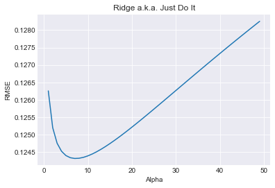

```python
sns.set_style("darkgrid")
plt.plot(ridge_alphas, ridge_rmse_cv)
plt.title("Ridge a.k.a. Just Do It")
plt.xlabel("Alpha")
plt.ylabel("RMSE")
plt.show()
```

```python
min_rmse_cv = np.min(ridge_rmse_cv)
bool_arr = np.array(ridge_rmse_cv) == min_rmse_cv
print ridge_alphas[bool_arr]
```

```
[7]
```

## 上傳

```python
ridge = Ridge(alpha = ridge_alphas[bool_arr])
ridge.fit(X_train, y_train)
y_hat = ridge.predict(X_test)
y_hat = np.expm1(y_hat)
Id = test.Id
my_solution = pd.DataFrame(y_hat, Id, columns = ["SalePrice"])
my_solution.to_csv("my_solution.csv", index_label = ["Id"])
```

# Digit Recognizer

## 簡介

> MNIST ("Modified National Institute of Standards and Technology") is the de facto “hello world” dataset of computer vision. Since its release in 1999, this classic dataset of handwritten images has served as the basis for benchmarking classification algorithms. As new machine learning techniques emerge, MNIST remains a reliable resource for researchers and learners alike.

## 資料載入

```python
train_url = "https://storage.googleapis.com/py_ml_datasets/mnist/train.csv"
test_url = "https://storage.googleapis.com/py_ml_datasets/mnist/test.csv"
train = pd.read_csv(train_url)
test = pd.read_csv(test_url)
```

## 資料外觀

```python
print train.shape
print test.shape
```

```
(42000, 785)
(28000, 784)
```

```python
train.head()
```

|  | label | pixel0 | pixel1 | pixel2 | pixel3 | pixel4 | pixel5 | pixel6 | pixel7 | pixel8 | ... | pixel774 | pixel775 | pixel776 | pixel777 | pixel778 | pixel779 | pixel780 | pixel781 | pixel782 | pixel783 |
| --- | --- | --- | --- | --- | --- | --- | --- | --- | --- | --- | --- | --- | --- | --- | --- | --- | --- | --- | --- | --- | --- |
| 0 | 1 | 0 | 0 | 0 | 0 | 0 | 0 | 0 | 0 | 0 | ... | 0 | 0 | 0 | 0 | 0 | 0 | 0 | 0 | 0 | 0 |
| 1 | 0 | 0 | 0 | 0 | 0 | 0 | 0 | 0 | 0 | 0 | ... | 0 | 0 | 0 | 0 | 0 | 0 | 0 | 0 | 0 | 0 |
| 2 | 1 | 0 | 0 | 0 | 0 | 0 | 0 | 0 | 0 | 0 | ... | 0 | 0 | 0 | 0 | 0 | 0 | 0 | 0 | 0 | 0 |
| 3 | 4 | 0 | 0 | 0 | 0 | 0 | 0 | 0 | 0 | 0 | ... | 0 | 0 | 0 | 0 | 0 | 0 | 0 | 0 | 0 | 0 |
| 4 | 0 | 0 | 0 | 0 | 0 | 0 | 0 | 0 | 0 | 0 | ... | 0 | 0 | 0 | 0 | 0 | 0 | 0 | 0 | 0 | 0 |

5 rows × 785 columns

```python
test.head()
```

|  | pixel0 | pixel1 | pixel2 | pixel3 | pixel4 | pixel5 | pixel6 | pixel7 | pixel8 | pixel9 | ... | pixel774 | pixel775 | pixel776 | pixel777 | pixel778 | pixel779 | pixel780 | pixel781 | pixel782 | pixel783 |
| --- | --- | --- | --- | --- | --- | --- | --- | --- | --- | --- | --- | --- | --- | --- | --- | --- | --- | --- | --- | --- | --- |
| 0 | 0 | 0 | 0 | 0 | 0 | 0 | 0 | 0 | 0 | 0 | ... | 0 | 0 | 0 | 0 | 0 | 0 | 0 | 0 | 0 | 0 |
| 1 | 0 | 0 | 0 | 0 | 0 | 0 | 0 | 0 | 0 | 0 | ... | 0 | 0 | 0 | 0 | 0 | 0 | 0 | 0 | 0 | 0 |
| 2 | 0 | 0 | 0 | 0 | 0 | 0 | 0 | 0 | 0 | 0 | ... | 0 | 0 | 0 | 0 | 0 | 0 | 0 | 0 | 0 | 0 |
| 3 | 0 | 0 | 0 | 0 | 0 | 0 | 0 | 0 | 0 | 0 | ... | 0 | 0 | 0 | 0 | 0 | 0 | 0 | 0 | 0 | 0 |
| 4 | 0 | 0 | 0 | 0 | 0 | 0 | 0 | 0 | 0 | 0 | ... | 0 | 0 | 0 | 0 | 0 | 0 | 0 | 0 | 0 | 0 |

5 rows × 784 columns

## 特徵工程

- 轉換資料框為 NumPy Array

```python
# 整理模型的輸入
X_train = train.iloc[:, 1:].values.astype('float32')
y_train = train.iloc[:, 0].values.astype('float32')
X_test = test.values.astype('float32')
print X_train.shape
print y_train.shape
print X_test.shape
```

```
(42000, 784)
(42000,)
(28000, 784)
```

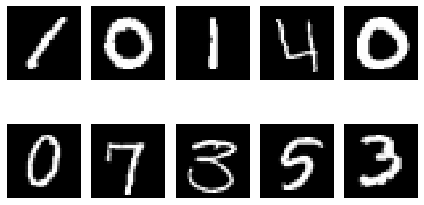

```python
# X_train
for i, k in enumerate(range(1, 11)):
    plt.subplot(2, 5, k)
    plt.imshow(X_train.reshape(train.shape[0], 28, 28)[i], cmap = "gray")
    plt.xticks([]), plt.yticks([])

plt.tight_layout()
plt.show()
```

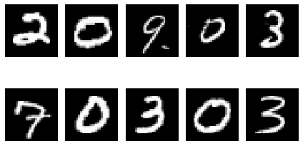

```python
# X_test
for i, k in enumerate(range(1, 11)):
    plt.subplot(2, 5, k)
    plt.imshow(X_test.reshape(test.shape[0], 28, 28)[i], cmap = "gray")
    plt.xticks([]), plt.yticks([])

plt.tight_layout()
plt.show()
```

## 模型

- 支持向量機
- K 最近鄰
- 隨機森林
- 卷積神經網絡（Convolutional Neural Network，CNN）

## 支持向量機

```python
svm_kernels = ['linear', 'poly', 'rbf', 'sigmoid']
for kernel in svm_kernels:
    svc = SVC(kernel = kernel)
    acc = np.mean(cross_val_score(svc, X_train[:3000, :], y_train[:3000], cv = 5, scoring = 'accuracy'))
    print "%s cv accurary: %.2f%%" % (kernel, acc * 100)
```

```
linear cv accurary: 90.47%
poly cv accurary: 93.40%
rbf cv accurary: 11.40%
sigmoid cv accurary: 11.40%
```

```python
svc = SVC(kernel = 'poly')
svc.fit(X_train, y_train)
y_hat = svc.predict(X_test)
ImageId = np.arange(1, 28001)
my_solution = pd.DataFrame(y_hat.astype('int'), ImageId, columns = ["Label"])
my_solution.to_csv("mnist/svm_solution.csv", index_label = ["ImageId"])
```

## K 最近鄰

```python
ks = [3, 5, 7, 9, 11]
for k in ks:
    knn = KNeighborsClassifier(n_neighbors = k)
    acc = np.mean(cross_val_score(knn, X_train[:3000, :], y_train[:3000], cv = 5, scoring = 'accuracy'))
    print "[n_neighbors = %i] accurary: %.2f%%" % (k, acc * 100)
```

```
[n_neighbors = 3] accurary: 91.37%
[n_neighbors = 5] accurary: 91.17%
[n_neighbors = 7] accurary: 90.77%
[n_neighbors = 9] accurary: 90.40%
[n_neighbors = 11] accurary: 90.03%
```

```python
knn = KNeighborsClassifier(n_neighbors = 3)
knn.fit(X_train, y_train)
y_hat = knn.predict(X_test)
ImageId = np.arange(1, 28001)
my_solution = pd.DataFrame(y_hat.astype('int'), ImageId, columns = ["Label"])
my_solution.to_csv("mnist/knn_solution.csv", index_label = ["ImageId"])
```

## 隨機森林

```python
estimators = [100, 200, 300, 500]
criterions = ['gini', 'entropy']
for criterion in criterions:
    for estimator in estimators:
        forest = RandomForestClassifier(n_estimators = estimator, criterion = criterion)
        acc = np.mean(cross_val_score(forest, X_train[:5000, :], y_train[:5000], cv = 5, scoring = 'accuracy'))
        print "[%s with %i estimators] accurary: %.2f%%" % (criterion, estimator, acc * 100)
```

```
[gini with 100 estimators] accurary: 93.66%
[gini with 200 estimators] accurary: 93.76%
[gini with 300 estimators] accurary: 93.78%
[gini with 500 estimators] accurary: 94.10%
[entropy with 100 estimators] accurary: 93.32%
[entropy with 200 estimators] accurary: 93.64%
[entropy with 300 estimators] accurary: 94.08%
[entropy with 500 estimators] accurary: 93.88%
```

```python
forest = RandomForestClassifier(n_estimators = 300, criterion = 'entropy')
forest.fit(X_train, y_train)
y_hat = forest.predict(X_test)
ImageId = np.arange(1, 28001)
my_solution = pd.DataFrame(y_hat.astype('int'), ImageId, columns = ["Label"])
my_solution.to_csv("mnist/forest_solution.csv", index_label = ["ImageId"])
```

## 卷積神經網絡（Convolutional Neural Network，CNN）

```python
# 整理模型的輸入
X_train = train.iloc[:, 1:].values.astype('float32')
y_train = pd.get_dummies(train.iloc[:, 0])
y_train = y_train.values.astype('float32')
X_test = test.values.astype('float32')
print X_train.shape
print y_train.shape
print X_test.shape
```

```
(42000, 784)
(42000, 10)
(28000, 784)
```

## 建構 CNN

- [Deep MNIST for Experts](https://www.tensorflow.org/get_started/mnist/pros)
- [[第 30 天] 深度學習（4）卷積神經網絡與鐵人賽總結](http://ithelp.ithome.com.tw/articles/10188044)
- [參考程式](https://github.com/yaojenkuo/intro_2_py_ds_esun/blob/master/mnist_kaggle.py)

## Titanic: Machine Learning from Disaster

```python
train_url = "https://storage.googleapis.com/py_ml_datasets/titanic/train.csv"
test_url = "https://storage.googleapis.com/py_ml_datasets/titanic/test.csv"
train = pd.read_csv(train_url)
test = pd.read_csv(test_url)
train.head()
```

|  | PassengerId | Survived | Pclass | Name | Sex | Age | SibSp | Parch | Ticket | Fare | Cabin | Embarked |
| --- | --- | --- | --- | --- | --- | --- | --- | --- | --- | --- | --- | --- |
| 0 | 1 | 0 | 3 | Braund, Mr. Owen Harris | male | 22.0 | 1 | 0 | A/5 21171 | 7.2500 | NaN | S |
| 1 | 2 | 1 | 1 | Cumings, Mrs. John Bradley (Florence Briggs Th... | female | 38.0 | 1 | 0 | PC 17599 | 71.2833 | C85 | C |
| 2 | 3 | 1 | 3 | Heikkinen, Miss. Laina | female | 26.0 | 0 | 0 | STON/O2. 3101282 | 7.9250 | NaN | S |
| 3 | 4 | 1 | 1 | Futrelle, Mrs. Jacques Heath (Lily May Peel) | female | 35.0 | 1 | 0 | 113803 | 53.1000 | C123 | S |
| 4 | 5 | 0 | 3 | Allen, Mr. William Henry | male | 35.0 | 0 | 0 | 373450 | 8.0500 | NaN | S |

```python
test.head()
```

|  | PassengerId | Pclass | Name | Sex | Age | SibSp | Parch | Ticket | Fare | Cabin | Embarked |
| --- | --- | --- | --- | --- | --- | --- | --- | --- | --- | --- | --- |
| 0 | 892 | 3 | Kelly, Mr. James | male | 34.5 | 0 | 0 | 330911 | 7.8292 | NaN | Q |
| 1 | 893 | 3 | Wilkes, Mrs. James (Ellen Needs) | female | 47.0 | 1 | 0 | 363272 | 7.0000 | NaN | S |
| 2 | 894 | 2 | Myles, Mr. Thomas Francis | male | 62.0 | 0 | 0 | 240276 | 9.6875 | NaN | Q |
| 3 | 895 | 3 | Wirz, Mr. Albert | male | 27.0 | 0 | 0 | 315154 | 8.6625 | NaN | S |
| 4 | 896 | 3 | Hirvonen, Mrs. Alexander (Helga E Lindqvist) | female | 22.0 | 1 | 1 | 3101298 | 12.2875 | NaN | S |

## 特徵工程

- 填補遺漏值
- 數值分箱
- One-hot Encoding

```python
def fe_cabin(df):
    df.Cabin = df.Cabin.fillna('N')
    df.Cabin = df.Cabin.apply(lambda x: x[0])
    return df

def fe_fare(df):
    median = df.Fare.median()
    df.Fare = df.Fare.fillna(median)
    return df

def fe_embarked(df):
    df.Embarked = df.Embarked.fillna("S")
    return df

def fe_name(df):
    df['last_name'] = df.Name.apply(lambda x: x.split(' ')[0])
    df.last_name = df.last_name.apply(lambda x: x[:-1])
    df['name_prefix'] = df.Name.apply(lambda x: x.split(' ')[1])
    return df

def fe_family(df):
    df['family_size'] = df.Parch + df.SibSp + 1
    return df
```

```python
all_data = pd.concat([
    train.drop(["Survived"], axis = 1),
    test
], axis = 0)

all_data = fe_cabin(all_data)
all_data = fe_fare(all_data)
all_data = fe_embarked(all_data)
all_data = fe_name(all_data)
all_data = fe_family(all_data)
```

```python
print all_data.isnull().sum()
```

```
PassengerId      0
Pclass           0
Name             0
Sex              0
Age            263
SibSp            0
Parch            0
Ticket           0
Fare             0
Cabin            0
Embarked         0
last_name        0
name_prefix      0
family_size      0
dtype: int64
```

```python
def fe_age(df):
    age_df = df[['Age', 'Pclass','Sex', 'Fare', 'last_name', 'name_prefix', 'family_size']]
    age_df = pd.get_dummies(age_df)
    known_age = age_df.loc[df.Age.notnull()]
    unknown_age = age_df.loc[df.Age.isnull()]
    y = known_age.values[:, 0]
    X = known_age.iloc[:, 1:].values
    rmses = []
    alphas = [0.05, 0.1, 0.5, 1, 5, 10, 30, 50, 75, 100]
    for alpha in alphas:
        ridge = Ridge(alpha = alpha)
        ridge.fit(X, y)
        mse = cross_val_score(ridge, X, y, cv = 10, scoring = 'neg_mean_squared_error')
        rmse = np.mean((-mse)**0.5)
        rmses.append(rmse)
    min_rmse = np.min(rmses)
    rmse_bool = np.array(rmses) == min_rmse
    good_alpha = np.array(alphas)[rmse_bool]
    ridge = Ridge(alpha = good_alpha)
    ridge.fit(X, y)
    X_fit = unknown_age.iloc[:, 1:]
    predicted_ages = ridge.predict(X_fit)
    predicted_ages = np.where(predicted_ages <= df.Age.min(), 0, predicted_ages)
    predicted_ages = np.where(predicted_ages >= df.Age.max(), df.Age.max(), predicted_ages)
    df.loc[(df.Age.isnull()), 'Age'] = predicted_ages
    return df

all_data = fe_age(all_data)
```

```python
print all_data.isnull().sum()
all_data.head()
```

```
PassengerId    0
Pclass         0
Name           0
Sex            0
Age            0
SibSp          0
Parch          0
Ticket         0
Fare           0
Cabin          0
Embarked       0
last_name      0
name_prefix    0
family_size    0
dtype: int64
```

|  | PassengerId | Pclass | Name | Sex | Age | SibSp | Parch | Ticket | Fare | Cabin | Embarked | last_name | name_prefix | family_size |
| --- | --- | --- | --- | --- | --- | --- | --- | --- | --- | --- | --- | --- | --- | --- |
| 0 | 1 | 3 | Braund, Mr. Owen Harris | male | 22.0 | 1 | 0 | A/5 21171 | 7.2500 | N | S | Braund | Mr. | 2 |
| 1 | 2 | 1 | Cumings, Mrs. John Bradley (Florence Briggs Th... | female | 38.0 | 1 | 0 | PC 17599 | 71.2833 | C | C | Cumings | Mrs. | 2 |
| 2 | 3 | 3 | Heikkinen, Miss. Laina | female | 26.0 | 0 | 0 | STON/O2. 3101282 | 7.9250 | N | S | Heikkinen | Miss. | 1 |
| 3 | 4 | 1 | Futrelle, Mrs. Jacques Heath (Lily May Peel) | female | 35.0 | 1 | 0 | 113803 | 53.1000 | C | S | Futrelle | Mrs. | 2 |
| 4 | 5 | 3 | Allen, Mr. William Henry | male | 35.0 | 0 | 0 | 373450 | 8.0500 | N | S | Allen | Mr. | 1 |

```python
all_data.describe()
```

|  | PassengerId | Pclass | Age | SibSp | Parch | Fare | family_size |
| --- | --- | --- | --- | --- | --- | --- | --- |
| count | 1309.000000 | 1309.000000 | 1309.000000 | 1309.000000 | 1309.000000 | 1309.000000 | 1309.000000 |
| mean | 655.000000 | 2.294882 | 29.487388 | 0.498854 | 0.385027 | 33.281086 | 1.883881 |
| std | 378.020061 | 0.837836 | 13.443539 | 1.041658 | 0.865560 | 51.741500 | 1.583639 |
| min | 1.000000 | 1.000000 | 0.000000 | 0.000000 | 0.000000 | 0.000000 | 1.000000 |
| 25% | 328.000000 | 2.000000 | 21.000000 | 0.000000 | 0.000000 | 7.895800 | 1.000000 |
| 50% | 655.000000 | 3.000000 | 28.736754 | 0.000000 | 0.000000 | 14.454200 | 1.000000 |
| 75% | 982.000000 | 3.000000 | 37.000000 | 1.000000 | 0.000000 | 31.275000 | 2.000000 |
| max | 1309.000000 | 3.000000 | 80.000000 | 8.000000 | 9.000000 | 512.329200 | 11.000000 |

```python
def bin_age(df):
    bins = (-1, 5, 12, 18, 25, 35, 60, 130)
    group_names = ['Baby', 'Child', 'Teenager', 'Student', 'Young Adult', 'Adult', 'Senior']
    categories = pd.cut(df.Age, bins, labels = group_names)
    df['age_binned'] = categories
    return df

def get_qtr(arr):
    qtr_1 = np.percentile(arr, 25)
    qtr_2 = np.percentile(arr, 50)
    qtr_3 = np.percentile(arr, 75)
    qtr_4 = np.max(arr)
    return qtr_1, qtr_2, qtr_3, qtr_4

def bin_fare(df, qtr_1, qtr_2, qtr_3, qtr_4):
    bins = (-1, qtr_1, qtr_2, qtr_3, qtr_4)
    group_names = ['1st_quartile', '2nd_quartile', '3rd_quartile', '4th_quartile']
    categories = pd.cut(df.Fare, bins, labels = group_names)
    df['fare_binned'] = categories
    return df
```

```python
qtr_1, qtr_2, qtr_3, qtr_4 = get_qtr(all_data.Fare.values)

all_data = bin_age(all_data)
all_data = bin_fare(all_data, qtr_1, qtr_2, qtr_3, qtr_4)
all_data.isnull().sum()
```

```
PassengerId    0
Pclass         0
Name           0
Sex            0
Age            0
SibSp          0
Parch          0
Ticket         0
Fare           0
Cabin          0
Embarked       0
last_name      0
name_prefix    0
family_size    0
age_binned     0
fare_binned    0
dtype: int64
```

```python
all_data = all_data.drop(['PassengerId', 'Name', 'SibSp', 'Parch', 'Ticket', 'Cabin', 'Age', 'Fare', 'last_name'], axis = 1)
all_data.head()
```

|  | Pclass | Sex | Embarked | name_prefix | family_size | age_binned | fare_binned |
| --- | --- | --- | --- | --- | --- | --- | --- |
| 0 | 3 | male | S | Mr. | 2 | Student | 1st_quartile |
| 1 | 1 | female | C | Mrs. | 2 | Adult | 4th_quartile |
| 2 | 3 | female | S | Miss. | 1 | Young Adult | 2nd_quartile |
| 3 | 1 | female | S | Mrs. | 2 | Young Adult | 4th_quartile |
| 4 | 3 | male | S | Mr. | 1 | Young Adult | 2nd_quartile |

```python
all_data = pd.get_dummies(all_data)
X_train = all_data.values[:train.shape[0], :]
X_test = all_data.values[train.shape[0]:, :]
y_train = train['Survived'].values
```

## 隨機森林

```python
forest = RandomForestClassifier()

parameters = {'n_estimators': [50, 100, 200, 300],
              'criterion': ['entropy', 'gini'],
              'max_depth': [5, 10, 15, 20],
              'min_samples_split': [2, 5, 10, 15, 20]
             }
acc_scorer = make_scorer(accuracy_score)
grid = GridSearchCV(forest, parameters, scoring = acc_scorer)
grid = grid.fit(X_train, y_train)
print grid.best_estimator_
```

```
RandomForestClassifier(bootstrap=True, class_weight=None, criterion='gini',
            max_depth=20, max_features='auto', max_leaf_nodes=None,
            min_impurity_decrease=0.0, min_impurity_split=None,
            min_samples_leaf=1, min_samples_split=10,
            min_weight_fraction_leaf=0.0, n_estimators=50, n_jobs=1,
            oob_score=False, random_state=None, verbose=0,
            warm_start=False)
```

```python
forest = grid.best_estimator_
forest.fit(X_train, y_train)
y_hat = forest.predict(X_test)

PassengerId = test["PassengerId"].values.astype(int)
my_solution = pd.DataFrame(y_hat, PassengerId, columns = ["Survived"])
my_solution.to_csv("my_solution.csv", index_label = ["PassengerId"])
```

# Miscellaneous

## Becoming a Unicorn

## Becoming a Unicorn（2）

- Unicorn was originally used to describe a full-stack engineer who is also a UI/UX designer
- A unicorn here we refer to one who is the mix of:
  - a statistician
  - an engineer
  - an analyst

## Becoming a Unicorn（3）

> A scientist may say "oh I'll leave it to the engineers to do that" and deliberate on theory instead. A data hacker doesn't give a damn and will roll up their sleeves and pour into the internals of a learning algorithm, splice and dice data in sql, R, Python, spark, and whiteboard a model validation architecture while pushing the limits of theory and technology along the way. Get dirty with data, technology and math, nothing should be too practical enough, too theoretical enough, or too mathematical enough for you to handle.

Quoted from: Ajai Sharma@LinkedIn

## Keep in Touch

- [Facebook](https://www.facebook.com/yaojen.kuo.1)
- [GitHub](https://github.com/yaojenkuo)

## Keep in Touch（2）

- Potential collaborations:
  - [余峻瑜](http://www.management.ntu.edu.tw/faculty/teacher/sn/129)教授的商管統計資料分析
  - [DataCamp](https://www.datacamp.com/)
  - [Udemy](https://www.udemy.com/)
  - 台北商業大學

## Keep in Touch（3）

- Upcoming events:
  - [輕鬆學習 R 語言](http://www.books.com.tw/products/0010763975)
  - [資料科學年會](http://datasci.tw/speakers/#tony)
  - R/Python 的課程會上線到 [Udemy](https://www.udemy.com/)

## 期末意見調查

https://goo.gl/forms/CnwLEZinjLm2N5zh1